# Quiz 240923

coop711

2024-09-23

## Red, Black을 잘못 표시한 사람들

랜덤화출석부에 있는 Red, Black 과 실제 구글예습퀴즈에 올린 Red, Black 이 다른 사람들이 있어서 파악해 보았습니다. 10월6일 오후 10시 현재 11명이 잘못 선택하였는데 Red 이면서 Black을 선택한 사람이 8명, Black 이면서 Red 를 선택한 사람이 3명 있었습니다. 11명을 랜덤하게 둘로 나눌 때 한 쪽 편에 3명 이하, 즉 다른 편에 8명 이상이 배정될 확률을 계산해 보면 공평한 동전 을 11번 던지는 이항분포에서 앞면이 세번 이하 나올 확률을 계산해 주면 되니까 $X$ 를 성공확률 0.5, 시행횟수 11인 이항분포의 확률 변수라고 하면 그 확률은
$$Pr(X \le 3) + Pr(X \ge 8)$$
를 계산하는 게 되어서 P-value 가 0.2266 임을 알 수 있고, 우리가 기준으로 삼는 0.05보다 훨씬 크다는 것을 알 수 있습니다.

|  | Red(구글예습퀴즈) | Black(구글예습퀴즈) |
| --- | --- | --- |
| **Red(랜덤화출석부)** | 367 | 8 |
| **Black(랜덤화출석부)** | 3 | 363 |

# 퀴즈 응답 비교

## Q1. 세종대왕 시대 조세제도

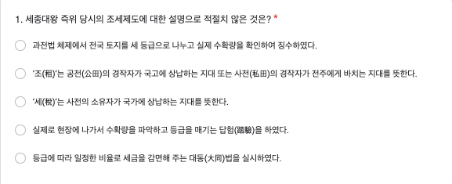

### 조선초기 조세제도

|  | 과전법 체제에서 전국 토지를 세 등급으로 나누고 실제 수확량을 확인하여 징수하였다. | ’조(租)’는 공전(公田)의 경작자가 국고에 상납하는 지대 또는 사전(私田)의 경작자가 전주에게 바치는 지대를 뜻한다. | ’세(稅)’는 사전의 소유자가 국가에 상납하는 지대를 뜻한다. | 실제로 현장에 나가서 수확량을 파악하고 등급을 매기는 답험(踏驗)을 하였다. | 등급에 따라 일정한 비율로 세금을 감면해 주는 대동(大同)법을 실시하였다. | 계 |
| --- | --- | --- | --- | --- | --- | --- |
| **Red** | 27 | 44 | 35 | 41 | 223 | 370 |
| **Black** | 32 | 35 | 43 | 37 | 224 | 371 |
| **계** | 59 | 79 | 78 | 78 | 447 | 741 |

Pearson’s Chi-squared test: `.`

| Test statistic | df | P value |
| --- | --- | --- |
| 2.476 | 4 | 0.649 |

### 조선초기 조세제도(%)

| 과전법 체제에서 전국 토지를 세 등급으로 나누고 실제 수확량을 확인하여 징수하였다. | ’조(租)’는 공전(公田)의 경작자가 국고에 상납하는 지대 또는 사전(私田)의 경작자가 전주에게 바치는 지대를 뜻한다. | ’세(稅)’는 사전의 소유자가 국가에 상납하는 지대를 뜻한다. | 실제로 현장에 나가서 수확량을 파악하고 등급을 매기는 답험(踏驗)을 하였다. | 등급에 따라 일정한 비율로 세금을 감면해 주는 대동(大同)법을 실시하였다. | 계 |
| --- | --- | --- | --- | --- | --- |
| 8.0 | 10.7 | 10.5 | 10.5 | 60.3 | 100.0 |

## Q2. 공법도입에 대한 대신들의 찬성율

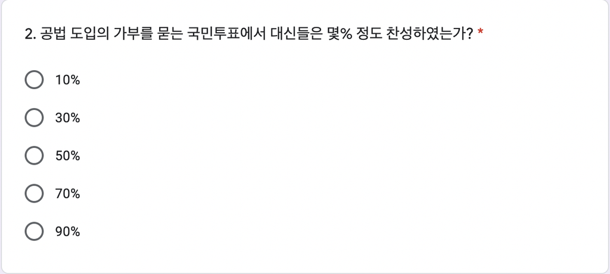

### 공법도입과 대신들(집계표)

|  | 10% | 30% | 50% | 70% | 90% | 계 |
| --- | --- | --- | --- | --- | --- | --- |
| **Red** | 202 | 70 | 35 | 46 | 17 | 370 |
| **Black** | 196 | 62 | 45 | 43 | 25 | 371 |
| **계** | 398 | 132 | 80 | 89 | 42 | 741 |

Pearson’s Chi-squared test: `.`

| Test statistic | df | P value |
| --- | --- | --- |
| 3.449 | 4 | 0.4857 |

### 공법도입과 대신들(%)

| 10% | 30% | 50% | 70% | 90% | 계 |
| --- | --- | --- | --- | --- | --- |
| 53.7 | 17.8 | 10.8 | 12.0 | 5.7 | 100.0 |

## Q3. 공법도입과 품관촌민들의 찬반

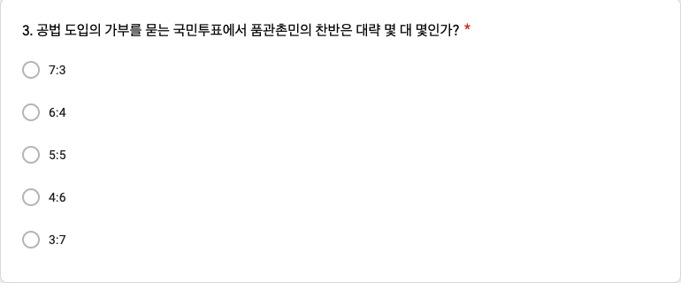

### 품관촌민들의 찬반(집계표)

|  | 7:3 | 6:4 | 5:5 | 4:6 | 3:7 | 계 |
| --- | --- | --- | --- | --- | --- | --- |
| **Red** | 45 | 236 | 28 | 32 | 29 | 370 |
| **Black** | 51 | 221 | 30 | 40 | 29 | 371 |
| **계** | 96 | 457 | 58 | 72 | 58 | 741 |

Pearson’s Chi-squared test: `.`

| Test statistic | df | P value |
| --- | --- | --- |
| 1.824 | 4 | 0.7681 |

### 품관촌민들의 찬반(%)

| 7:3 | 6:4 | 5:5 | 4:6 | 3:7 | 계 |
| --- | --- | --- | --- | --- | --- |
| 13.0 | 61.7 | 7.8 | 9.7 | 7.8 | 100.0 |

## Q4. 공법

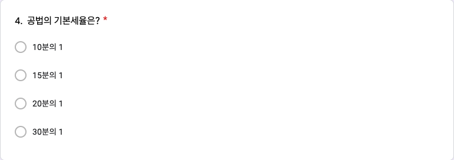

### 기본세율

|  | 1/10 | 1/15 | 1/20 | 1/30 | 계 |
| --- | --- | --- | --- | --- | --- |
| **Red** | 138 | 46 | 171 | 15 | 370 |
| **Black** | 123 | 52 | 177 | 19 | 371 |
| **계** | 261 | 98 | 348 | 34 | 741 |

Pearson’s Chi-squared test: `.`

[output not shown]

### 기본세율(%)

| 1/10 | 1/15 | 1/20 | 1/30 | 계 |
| --- | --- | --- | --- | --- |
| 35.2 | 13.2 | 47.0 | 4.6 | 100.0 |

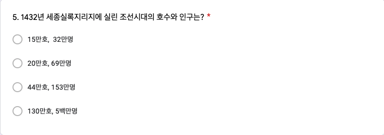

### 호구와 인구

|  | 15만호 | 20만호 | 44만호 | 130만호 | 계 |
| --- | --- | --- | --- | --- | --- |
| **Red** | 19 | 203 | 120 | 28 | 370 |
| **Black** | 27 | 209 | 114 | 21 | 371 |
| **계** | 46 | 412 | 234 | 49 | 741 |

Pearson’s Chi-squared test: `.`

| Test statistic | df | P value |
| --- | --- | --- |
| 2.631 | 3 | 0.452 |

### 호구와 인구(%)

| 15만호 | 20만호 | 44만호 | 130만호 | 계 |
| --- | --- | --- | --- | --- |
| 6.2 | 55.6 | 31.6 | 6.6 | 100.0 |

## Q6. 지방관료와 품관촌민

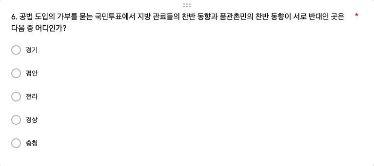

### 찬반이 반대인 곳(집계표)

|  | 경기 | 평안 | 전라 | 경상 | 충청 | 계 |
| --- | --- | --- | --- | --- | --- | --- |
| **Red** | 29 | 43 | 77 | 56 | 165 | 370 |
| **Black** | 35 | 47 | 78 | 51 | 160 | 371 |
| **계** | 64 | 90 | 155 | 107 | 325 | 741 |

Pearson’s Chi-squared test: `.`

| Test statistic | df | P value |
| --- | --- | --- |
| 1.056 | 4 | 0.9012 |

### 찬반이 반대인 곳(%)

| 경기 | 평안 | 전라 | 경상 | 충청 | 계 |
| --- | --- | --- | --- | --- | --- |
| 8.6 | 12.1 | 20.9 | 14.4 | 43.9 | 100.0 |

# 주당 근로 69시간제 도입 찬반

## Q7. 부연설명의 효과

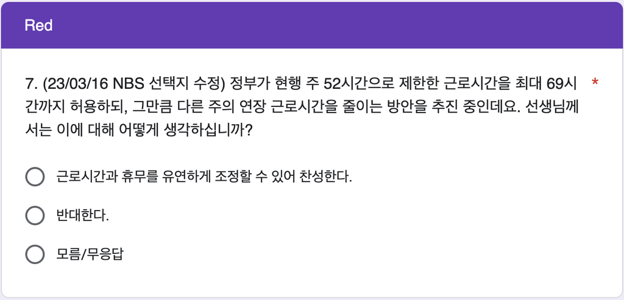

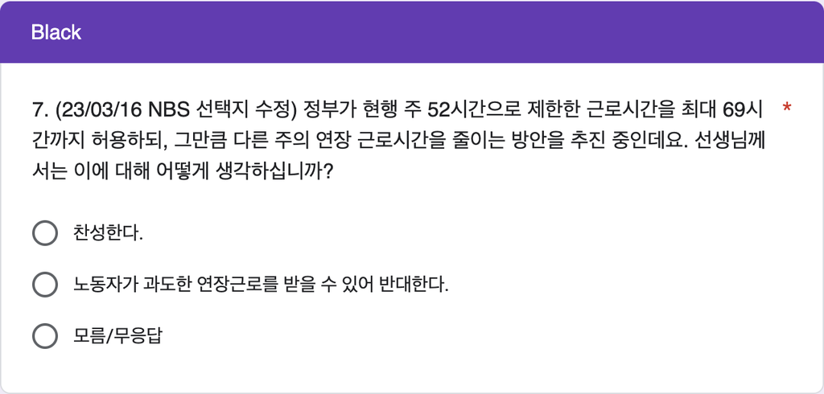

부연설명을 찬성 쪽에 붙이는가(Red), 또는 반대 쪽에 붙이는가(Black)에 따라 응답이 영향을 받는 것으로 관찰됩니다. 찬반여부에 대한 카이제곱테스트의 p-value를 놓고 볼 때 그 차이가 통계적으로 매우 유의합니다.

|  | 찬성한다. | 반대한다. | 모름/무응답 | 계 |
| --- | --- | --- | --- | --- |
| **Red(찬성한다에 부연설명)** | 161 | 137 | 72 | 370 |
| **Black(반대한다에 부연설명)** | 85 | 198 | 88 | 371 |
| **계** | 246 | 335 | 160 | 741 |

Pearson’s Chi-squared test: `.`

| Test statistic | df | P value |
| --- | --- | --- |
| 36.19 | 2 | 1.388e-08 * * * |

### % 비교

|  | 찬성한다. | 반대한다. | 모름/무응답 | 계 |
| --- | --- | --- | --- | --- |
| **Red(찬성한다에 부연설명)** | 43.5 | 37.0 | 19.5 | 100.0 |
| **Black(반대한다에 부연설명)** | 22.9 | 53.4 | 23.7 | 100.0 |

### % 합계

두 그룹의 차이가 통계적으로 매우 유의하기 때문에 합쳐 보는 것이 적절치 않으나 찬반의 총계를 보기 위하여 합침.

| 찬성한다. | 반대한다. | 모름/무응답 | 계 |
| --- | --- | --- | --- |
| 33.2 | 45.2 | 21.6 | 100.0 |

### Mosaic Plot

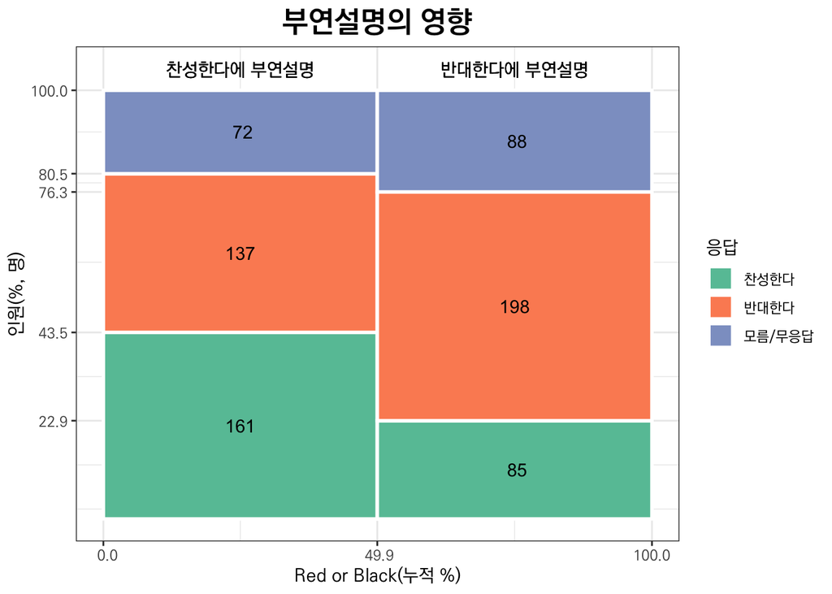

# 제출 시간의 분포

과제 제출이 제출 기간 마지막 날에 몰린다는 것을 시각적으로 보여주고 싶어서 하나 추가하였습니다. 5주차에 접어들어가는 시점에서 마지막 날에 몰리는 현상이 뚜럇해지고 있습니다. 여기서조차 랜덤화 효과를 관찰할 수 있네요. p-value 에 유의해 주세요. 제출시간과 관련한 두 가지 현상에 대해서도 여러분의 생각을 들어보고 싶습니다. 첫째, 랜덤화 효과. 둘쨰, 마감날에 몰리는 현상.

## 일 단위 마감 시간으로부터 제출 시간의 분포

### 분포표 (Red, Black 은 닮았는가?)

일 단위

|  | [0,1] | (1,2] | (2,3] | (3,4] | (4,5] | (5,6] | (6,7] | (7,8] | (8,9] | (9,10] | (10,11] | (11,12] | (12,13] | (13,14] |
| --- | --- | --- | --- | --- | --- | --- | --- | --- | --- | --- | --- | --- | --- | --- |
| **Red** | 76 | 31 | 17 | 10 | 12 | 8 | 12 | 34 | 36 | 20 | 30 | 21 | 26 | 37 |
| **Black** | 94 | 22 | 8 | 9 | 5 | 5 | 11 | 56 | 27 | 23 | 24 | 24 | 31 | 32 |

Pearson’s Chi-squared test: `.`

| Test statistic | df | P value |
| --- | --- | --- |
| 18.88 | 13 | 0.1267 |

### 막대그래프

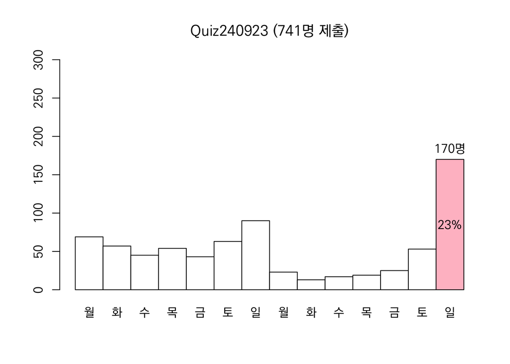

### Mosaic Plot

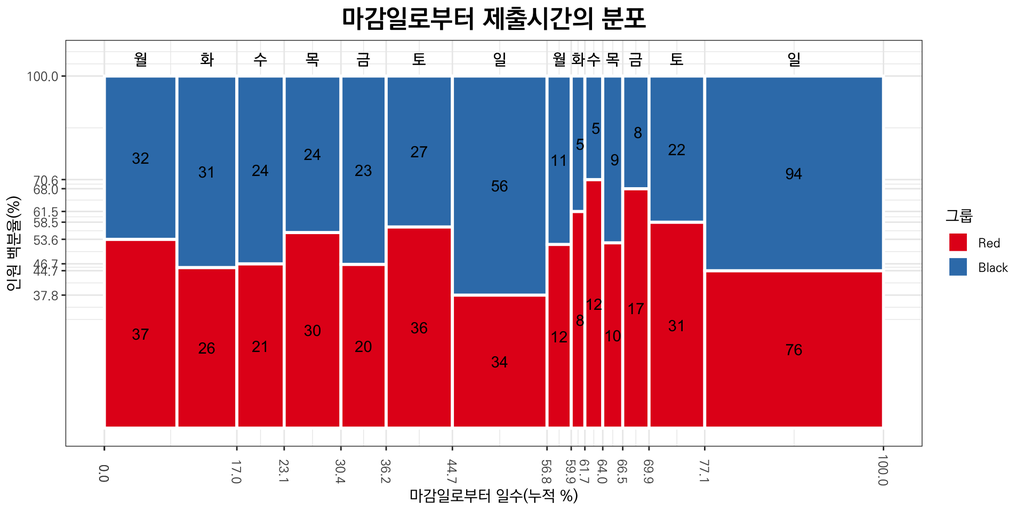